# R ile Veri Analizinde *Tidyverse* Yaklaşımı

## 6.7 Yoğunluk: `geom_density()`

- Yoğunluk fonksiyonu düzleştirilmiş histogram gibi düşünülebilir. Örneğin,

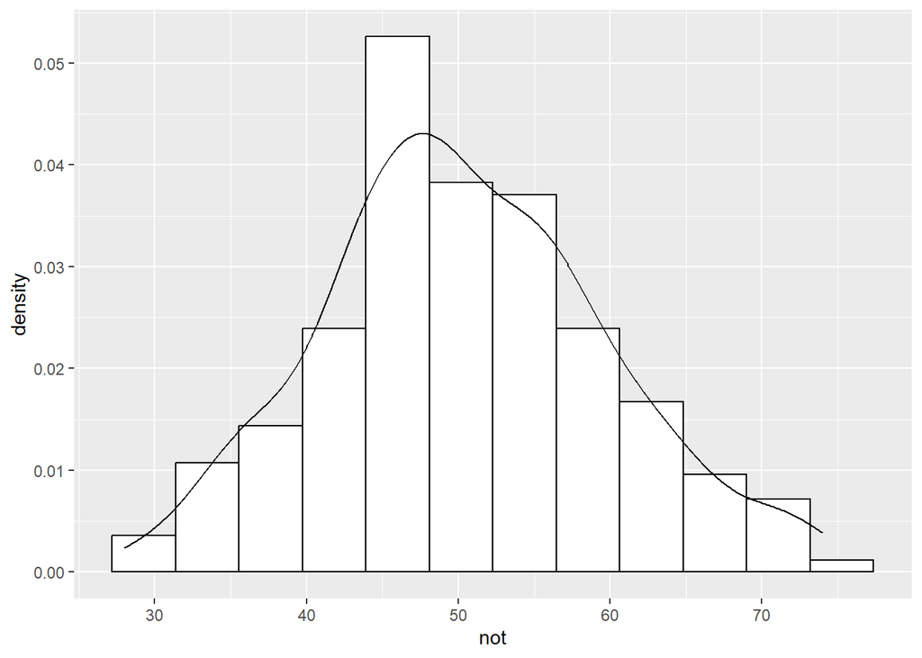

```r
not_verileri |> filter(ders == "Ekonometri-1") |>
  ggplot(aes(x = not)) +
  geom_histogram(aes(y=..density..),  # histogramda y ekseninde yoğunluğu göster
                 bins = 12,
                 color = "black",
                 fill = "white") +
  geom_density(aes(x = not))
```

- Gruplar için yoğunluk fonksiyonunu aynı grafik üzerinde göster:

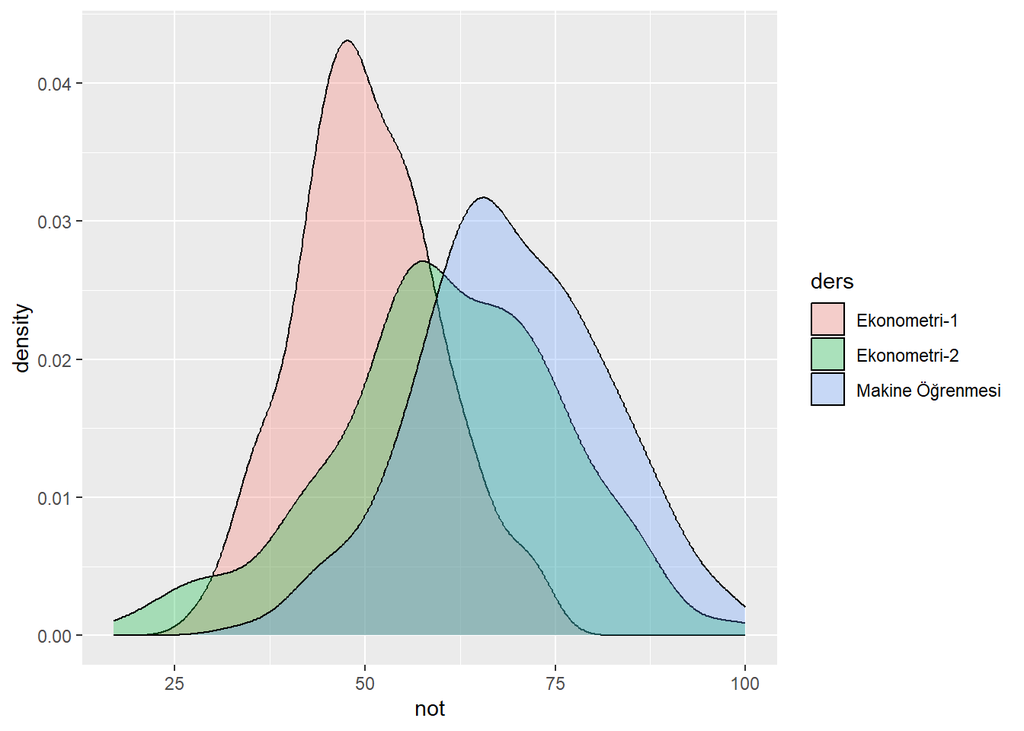

```r
not_verileri |> ggplot(aes(x = not, fill = ders)) +
  geom_density(alpha = 0.3)
```

- Yukarıdaki grafiğe örneklem ortalamalarını her grup için ekleyelim. Bunun için yukarıda oluşturduğumuz `not_ort` tablosunu `geom_vline()` içinde kullanabiliriz.

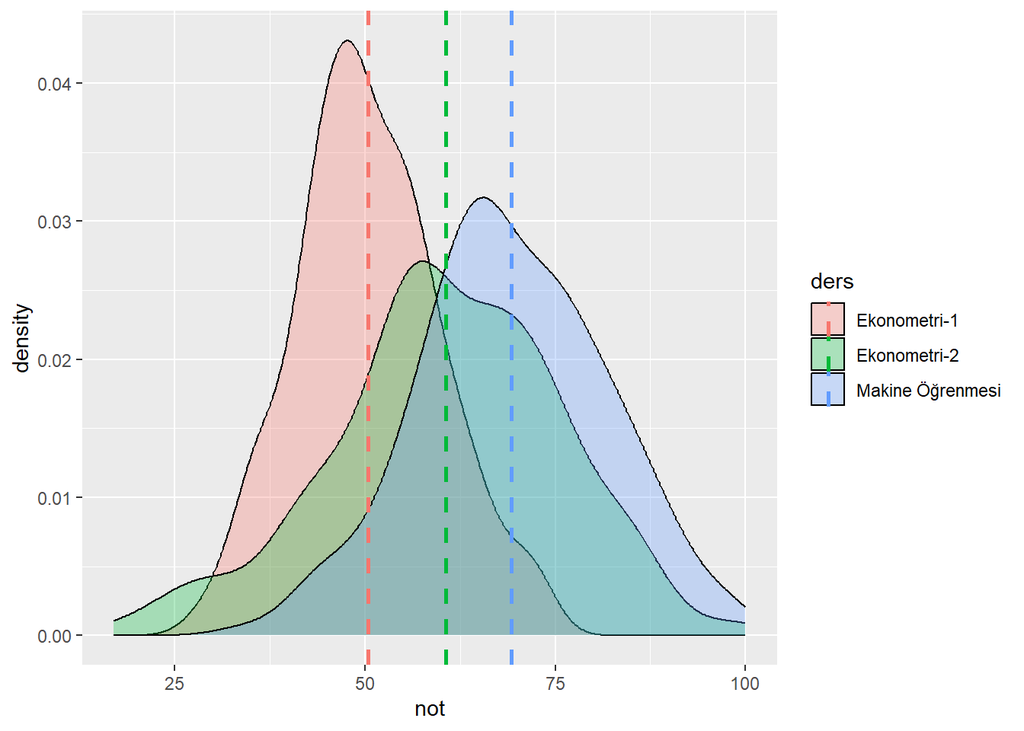

```r
not_verileri |> ggplot(aes(x = not, fill = ders)) +
  geom_density(alpha = 0.3) +
  geom_vline(data = not_ort,     # özet istatistik tablosu
             aes(xintercept = ortalama,
                 colour = ders
                 ),
             linetype="dashed",
             size=1)
```

## 6.8 Kutu Çizimi: `geom_boxplot()`

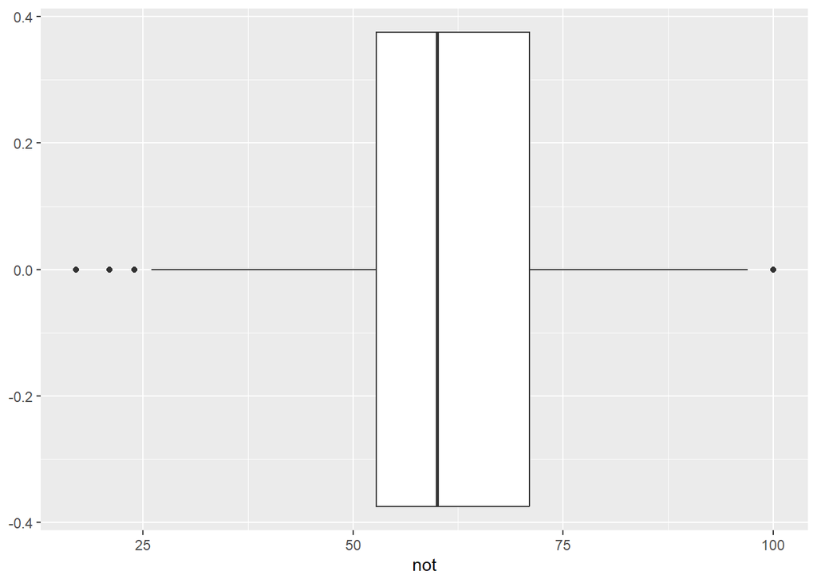

```r
not_verileri |> filter(ders == "Ekonometri-2") |>
  ggplot(mapping = aes(x = not)) +
  geom_boxplot()
```

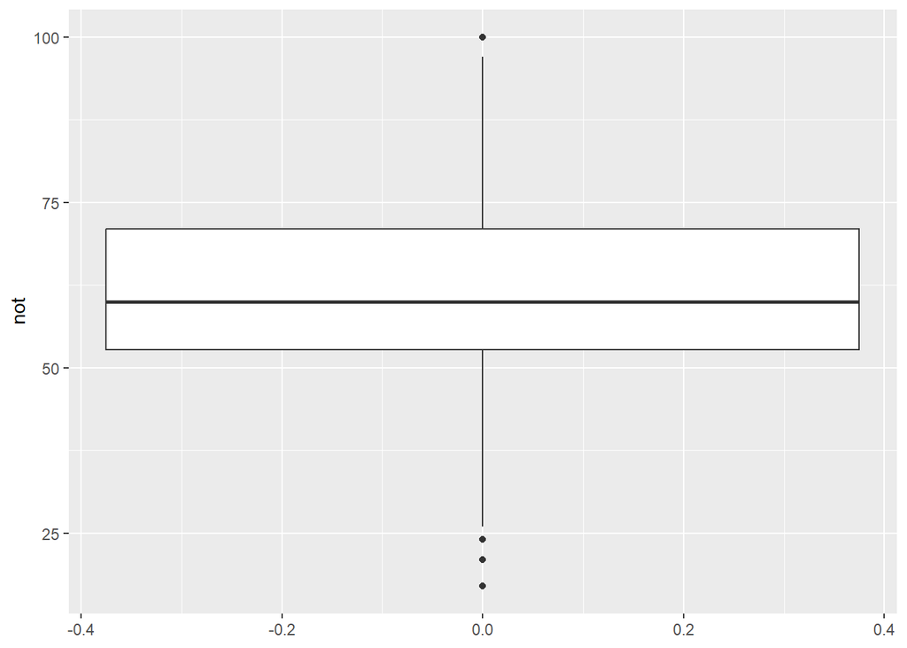

```r
not_verileri |> filter(ders == "Ekonometri-2") |>
  ggplot(mapping = aes(y = not)) +
  geom_boxplot()
```

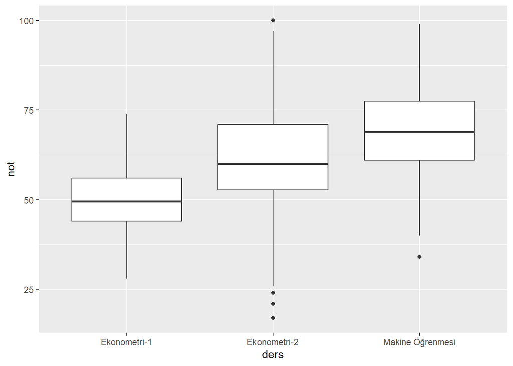

```r
not_verileri |>
  ggplot(mapping = aes(x = ders, y = not)) +
  geom_boxplot()
```

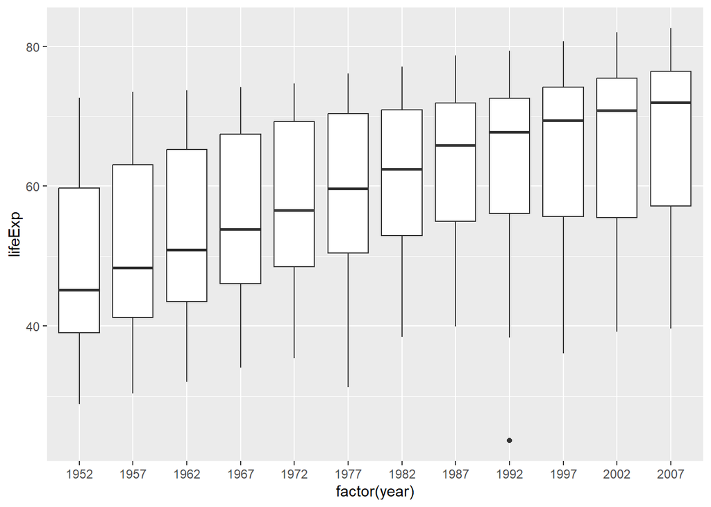

```r
gapminder |>
  ggplot(mapping = aes(x = factor(year), y = lifeExp)) +
  geom_boxplot()
```

## 6.9 Keman grafiği: `geom_violin()`

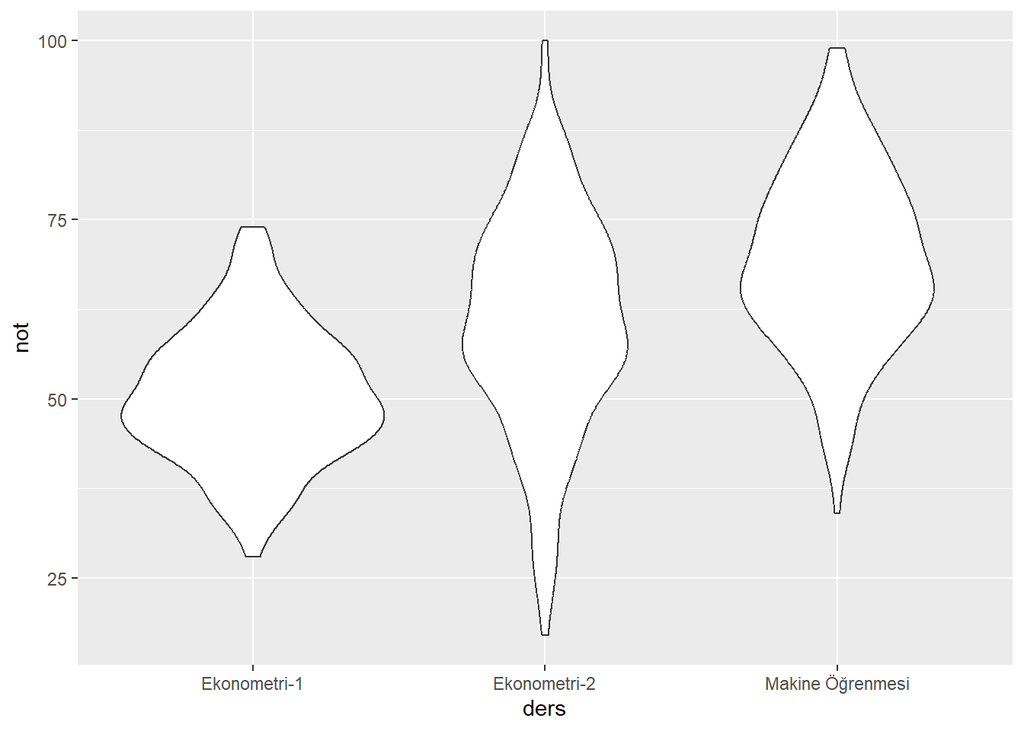

```r
not_verileri |>
  ggplot(mapping = aes(x = ders, y = not)) +
  geom_violin()
```

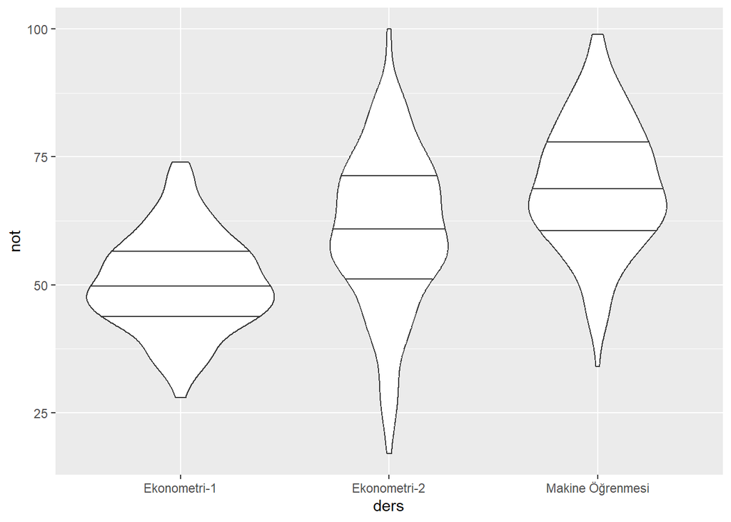

```r
# kartilleri göster
not_verileri |>
  ggplot(mapping = aes(x = ders, y = not)) +
  geom_violin(draw_quantiles = c(0.25, 0.5, 0.75))
```

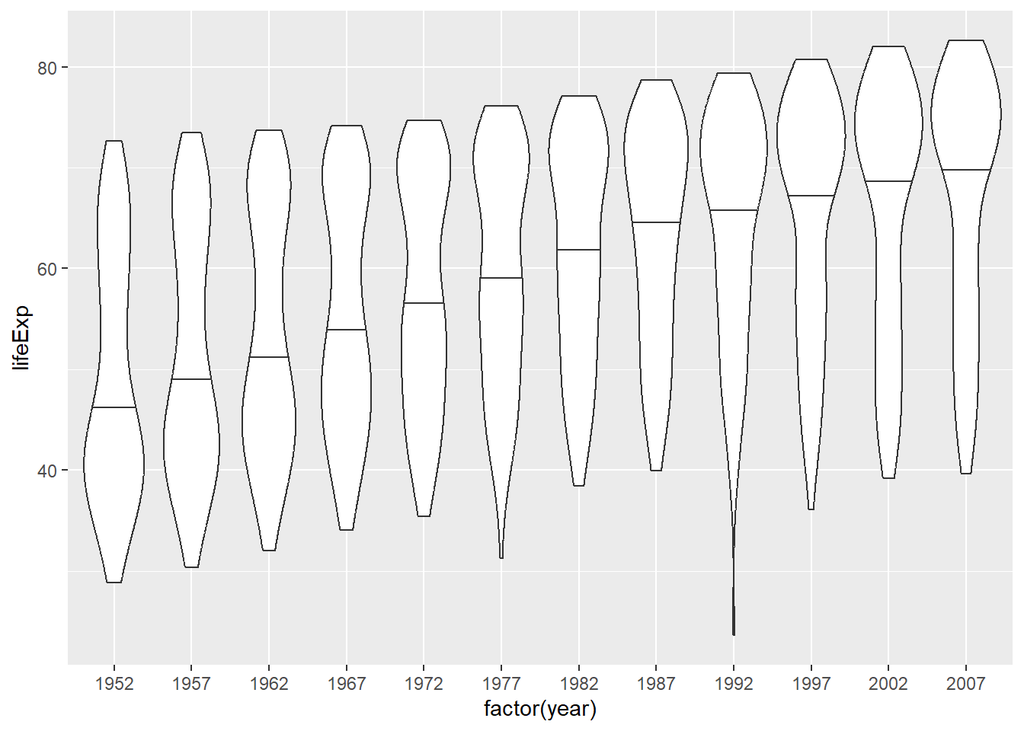

```r
gapminder |>
  ggplot(mapping = aes(x = factor(year), y = lifeExp)) +
  geom_violin(draw_quantiles = c(0.5))
```

## 6.10 QQ Grafiği

- Birikimli dağılım fonksiyonunu çizerek normal dağılımla karşılaştırmak isteyebiliriz. Bunun için `geom_qq()` veya `stat_qq()` fonksiyonlarını kullanabiliriz.
- Örnek olarak 5 serbestlik dereceli bir t dağılımından rastgele örneklem çekelim ve grafiğini çizelim.

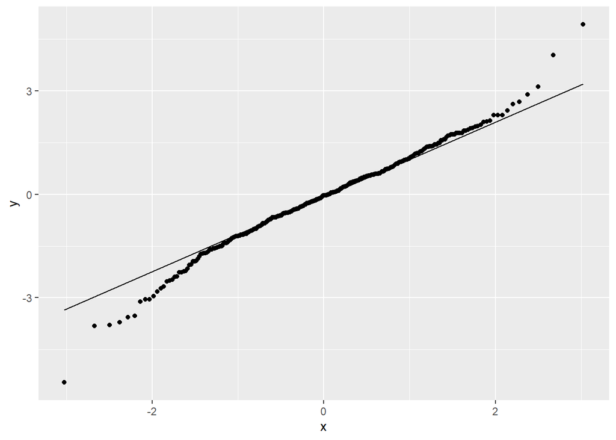

```r
set.seed(54321)
data <- tibble(x = rt(400, df = 5))
data |> ggplot(aes(sample = x)) +
  geom_qq() +
  geom_qq_line()
```

## 6.11 Bar plot

- Sütun grafiği (bar plot): örnek olarak notları derslere ve cinsiyete göre gruplayıp özet istatistiklerini hesaplayalım. Daha sonra grup ortalamalarını bar plot haline getirelim:

```r
not_ort2 <- not_verileri |>
  group_by(ders, cinsiyet) |>
  summarize(ortalama = mean(not),
            medyan = median(not),
            p25 = quantile(not, 0.25),
            p75 = quantile(not, 0.75)
            )
not_ort2
```

```
## # A tibble: 6 × 6
## # Groups:   ders [3]
##   ders             cinsiyet ortalama medyan   p25   p75
##   <fct>            <chr>       <dbl>  <dbl> <dbl> <dbl>
## 1 Ekonometri-1     Erkek        51.1     50    44  58
## 2 Ekonometri-1     Kadın        49.6     48    44  55
## 3 Ekonometri-2     Erkek        61.1     62    50  71
## 4 Ekonometri-2     Kadın        60.2     59    54  71
## 5 Makine Öğrenmesi Erkek        69.9     71    62  78
## 6 Makine Öğrenmesi Kadın        68.7     68    61  76.2
```

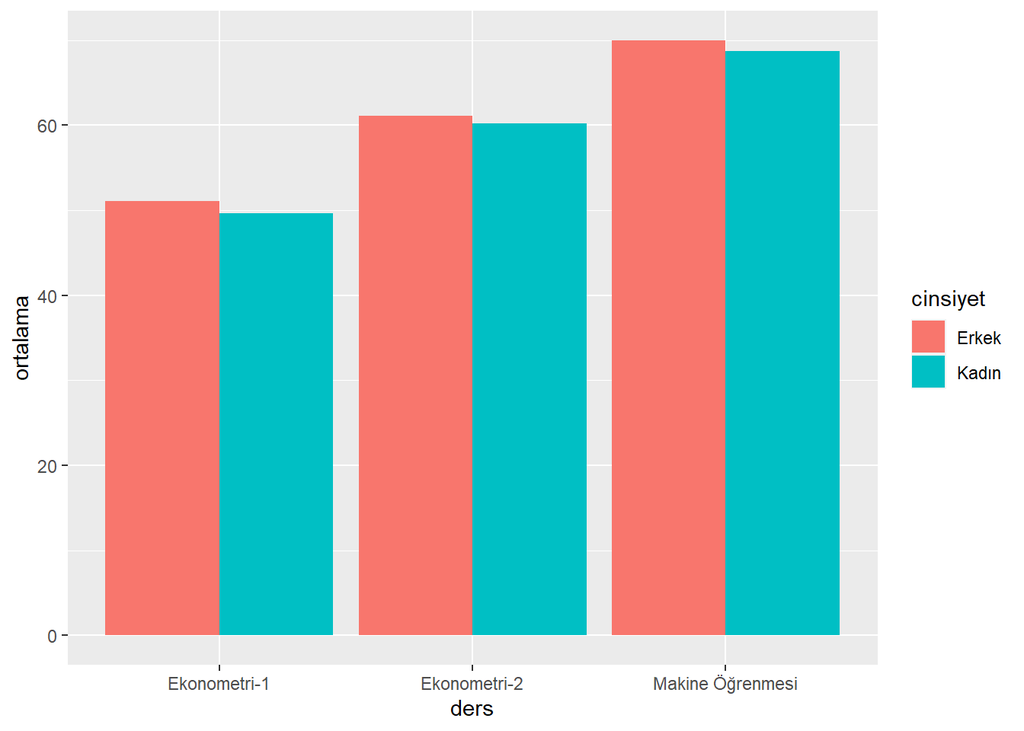

```r
not_ort2 |>
  ggplot(aes(x = ders, y = ortalama, fill = cinsiyet)) +
  geom_bar(stat = "identity",           # istatistik hesaplama
           position = position_dodge()  # sütunları yan yana göster
           )
```

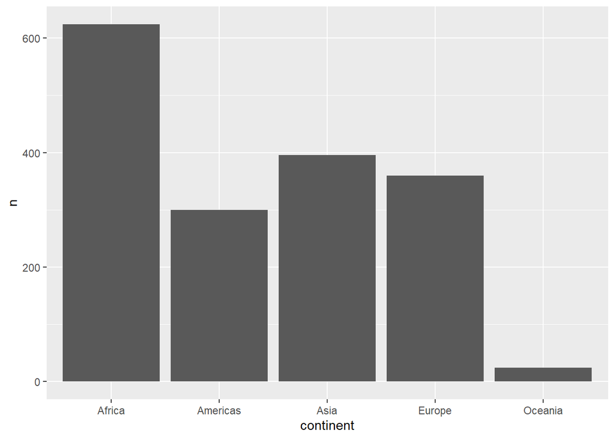

```r
gapminder |> group_by(continent) |>
  summarize(n = n()) |>
  ggplot(aes(x = continent, y = n)) +
  geom_bar(stat = "identity",
           position = position_dodge())
```

- Her grup için ortalama çevresinde %95 güven aralığını çizmek istersek `geom_pointrange()` ya da `geom_errorbar()` fonksiyonlarını kullanabiliriz:

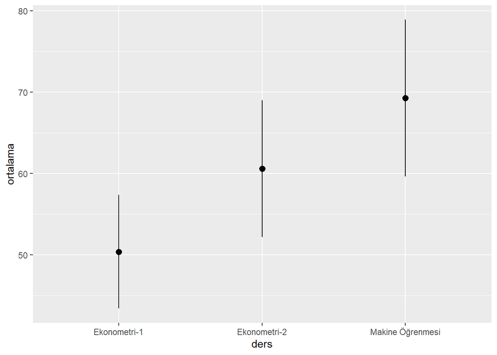

```r
not_ort |> ggplot(aes(ders,     # grup
                       ortalama, # istatistik
                       ymin = ortalama-1.96*se_ort, # alt sınır
                       ymax = ortalama+1.96*se_ort  # üst sınır
                       )
                   ) +
  geom_pointrange()
```

- `stat_summary()` fonksiyonu ile medyan, minimum ve maksimum değerlerin gösterilmesi:

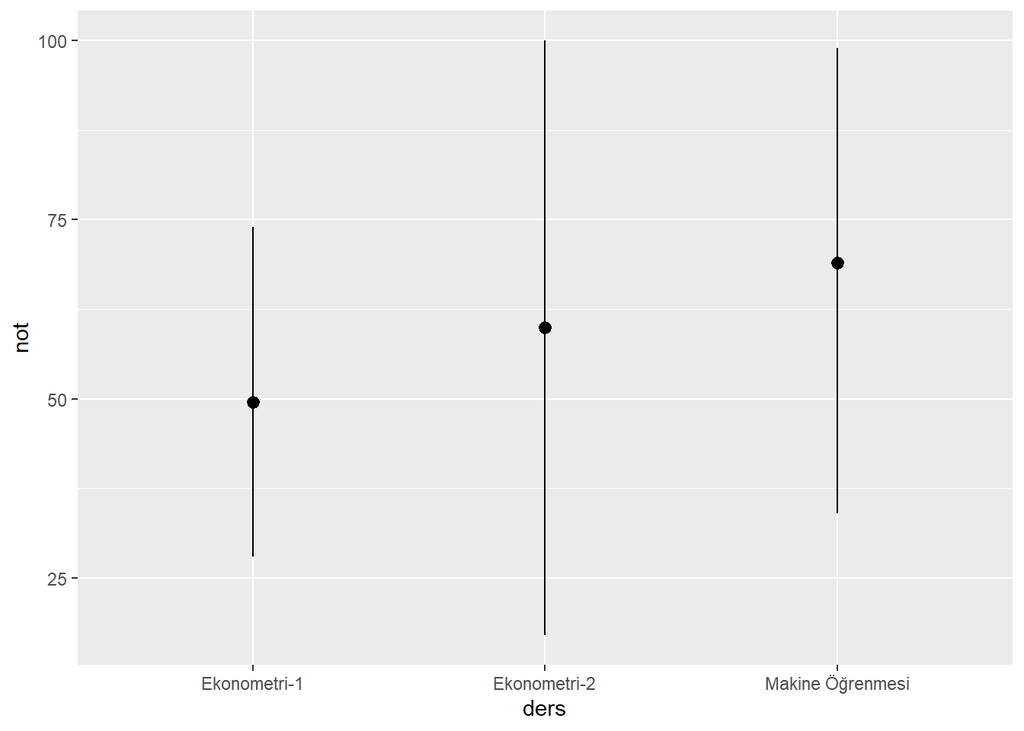

```r
ggplot(data = not_verileri) +
  stat_summary(
    mapping = aes(x = ders, y = not),
    fun.min = min,
    fun.max = max,
    fun = median
  )
```

## 6.12 Çizgi ve Nokta grafiği

- Örnek: Türkiye’nin kişi başına GDP değerlerinin zaman serisi grafiğini çiz.

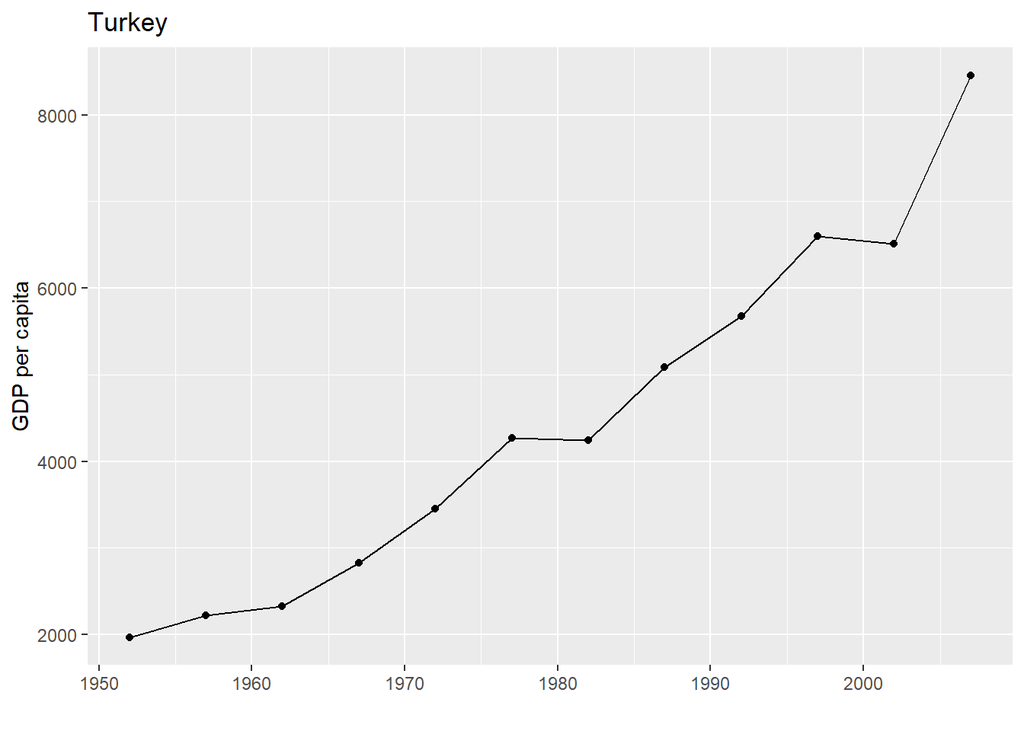

```r
library(gapminder)
turkey <- gapminder |> filter(country=="Turkey")
ggplot(turkey, aes(x = year, y = gdpPercap)) +
  geom_line() +
  geom_point() +
  xlab("") +
  ylab("GDP per capita") +
  ggtitle("Turkey")
```

- Örnek: Düşük gelirli Avrupa ülkelerinde yaşam beklentisinin zaman serisi grafiğini çiz. Düşük gelir durumu: 2007 yılında gdpPercap<10000 ise düşük gelirli ülke; değilse yüksek gelirli ülke.

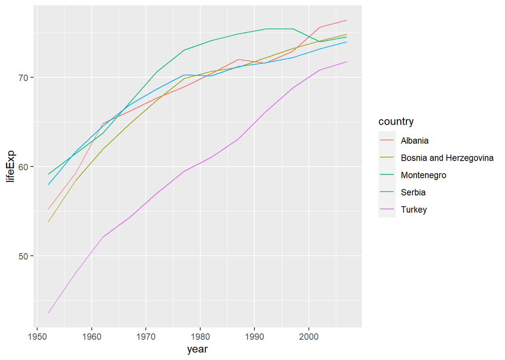

```r
# verileri oluştur
europe <- gapminder |>
  filter(continent == "Europe")
clist <- filter(europe, gdpPercap<10000 & year==2007)
lowincome_europe <- filter(europe, country %in% clist$country)
# grafiği çiz
ggplot(lowincome_europe, aes(x = year, y = lifeExp, color = country)) +
  geom_line()
```

- Örnek: Avrupa’da 2007 yılındaki yaşam beklentisi küçükten büyüğe sıralayıp nokta grafiğini çiz.

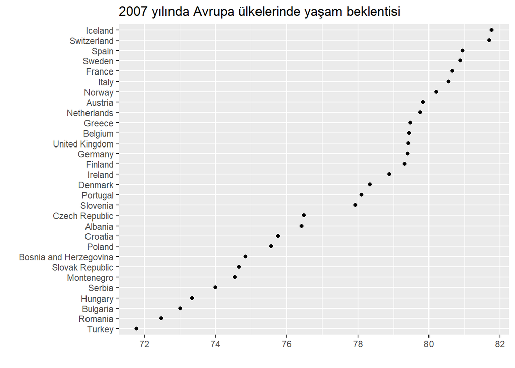

```r
# önce verileri oluştur
europe2007 <- gapminder |>
  filter(year == 2007, continent == "Europe")
# grafiği çiz
ggplot(europe2007,
       aes(x = lifeExp,
           y = fct_reorder(country, lifeExp) # ülkeleri lifeEXp'e göre sıraya diz
           )) +
  geom_point() +
  ylab("") + xlab("") +
  ggtitle("2007 yılında Avrupa ülkelerinde yaşam beklentisi")
```

Alıştırma: yukarıdaki grafiğe 1952 yılının bilgisini ekleyerek bu dönemde yaşam beklentisinin nasıl değiştiğini görmek istiyorsunuz. Bu bilgiyi grafiğe nasıl eklersiniz?

- Örnek: Aşağıdaki veri setinin nokta+çizgi grafiğini çizelim.

```r
df <- tibble(`yıl` = factor(c(2010, 2020, 2010, 2020)),
             x = c(100, 150, 200, 160),
             tip = factor(c("A", "A", "B", "B")))
df
```

```
## # A tibble: 4 × 3
##   yıl       x tip
##   <fct> <dbl> <fct>
## 1 2010    100 A
## 2 2020    150 A
## 3 2010    200 B
## 4 2020    160 B
```

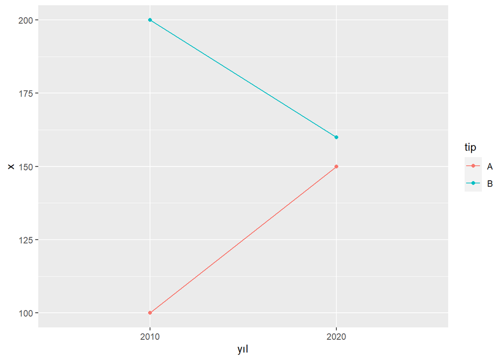

```r
df  |>
  ggplot(aes(`yıl`,x, color = tip, group=tip)) +
  geom_point() +
  geom_line()
```

## 6.13 Temalar

- `ggplot2::theme()` fonksiyonu ile grafiğimizin verilerle ilgili olmayan arkaplan, grid çizgileri, çerçeve çizgileri gibi özelliklerini değiştirebiliriz.
- Önceden tanımlanmış `theme_bw()`, `theme_classic()` gibi temaları kullanabiliriz
- Örnek olarak yukarıda oluşturduğumuz `lowincome_europe` grafiğini siyah-beyaz baskıya uygun hale getirelim:

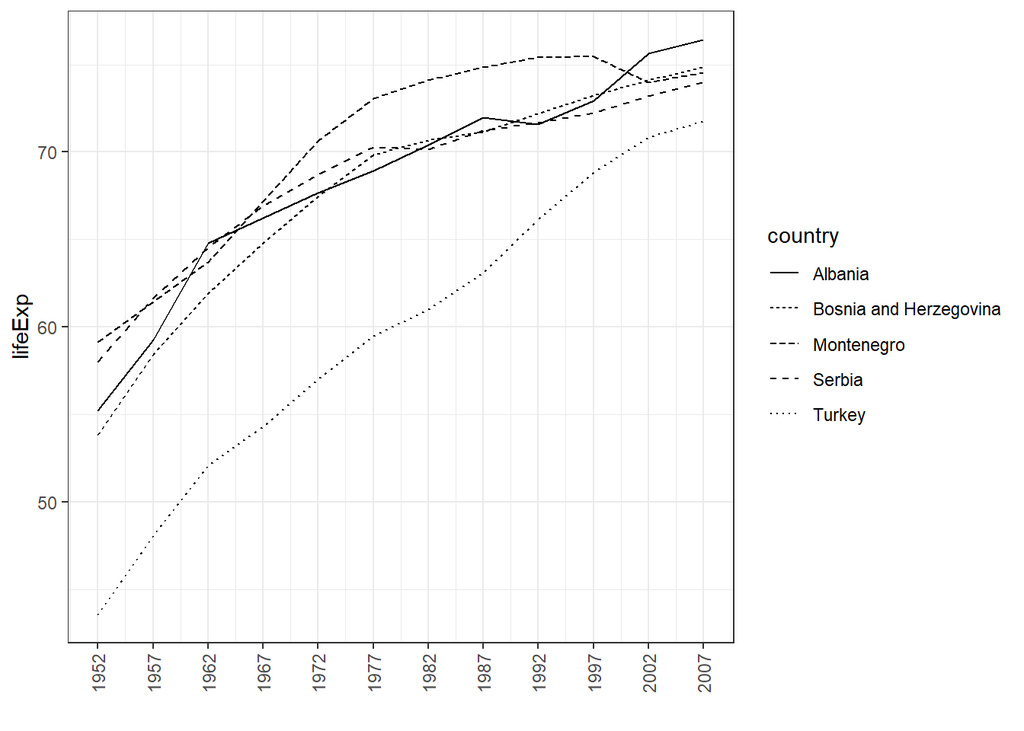

```r
ggplot(lowincome_europe,
       aes(x = year,
           y = lifeExp,
           linetype = country # çizgi tipini ülkelere göre belirle
           )) +
  geom_line() +
  theme_bw() +   # siyah-beyaz temayı kullan
  scale_x_continuous(breaks = seq(1952, 2007, 5)) + # x etiketlerini belirle
  theme(axis.text.x = element_text(angle = 90, vjust = 0.5, hjust = 1)) + # yönünü dikey yap
  xlab("")
```

## 6.14 Harita çizimi

- `R` ile jeokonumsal verilerin görselleştirilmesinde çeşitli araçlar mevcuttur.
- `{sf}` (simple features) paketi: https://github.com/r-spatial/sf. `ggplot2` fonksiyonları `geom_sf()` ve `coord_sf()` bu paket ile uyumlu çalışır.
- Örnek olarak Türkiye’nin il düzeyinde bir haritasını çizmek istediğimizi düşünelim.

```r
library(tidyverse)
load("Data/tr_harita_veri.RData")
```

- `tr_harita_veri` illerin sınırlarına ilişkin koordinat bilgisini içermektedir (`geometry` sütununda). İllerin isimlerinin yanı sıra `geometry` sütunu altında il sınır bilgileri yer almaktadır. Bu noktada il düzeyinde boş haritayı çizebiliriz:

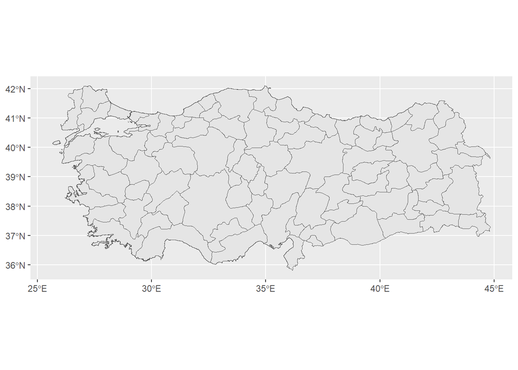

```r
# boş il haritası
ggplot(tr_harita_veri) +
  geom_sf() +
  coord_sf()
```

- `geom_sf()` fonksiyonu veri setinde yer alan `geometry` bilgisini kullanarak il sınırlarını koordinat sistemi üzerinde yerleştirdi.
- İstenirse harita üzerinde başka geometrik şekiller ile katmanlar eklenebilir. Örneğin, bazı şehir merkezlerini nokta ile işaretleyelim. Bunun için önce şehirlerin eylem-boylam bilgisini içeren bir tablo oluşturalım:

```r
tr_sehirler <- tribble(
  ~city,       ~lat, ~lon,
  "Istanbul",  41.0,  29.0,
  "Ankara",    39.9,  32.8,
  "İzmir",     38.4,  27.1,
  "Bursa",     40.2,  29.1,
  "Antalya",   36.9,  30.7,
  "Konya",     37.9,  32.5
)
```

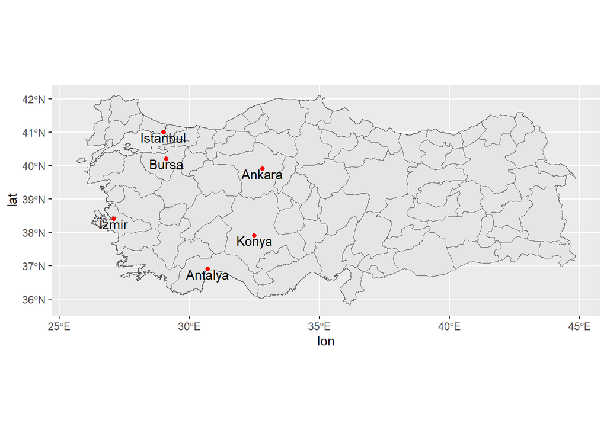

```r
# tr_sehirler içindeki şehirleri kırmızı nokta ile göster
ggplot(tr_harita_veri) +
  geom_sf() +
  geom_point(data = tr_sehirler,
             mapping = aes(x = lon, y = lat),
             colour = "red") +
  geom_text(data = tr_sehirler,
            mapping = aes(x = lon, y = lat, label = city),
            nudge_y = -0.15) + # y koordinatında şehir isimlerini aşağıya kaydır
  coord_sf()
```

Başka bir versiyon:

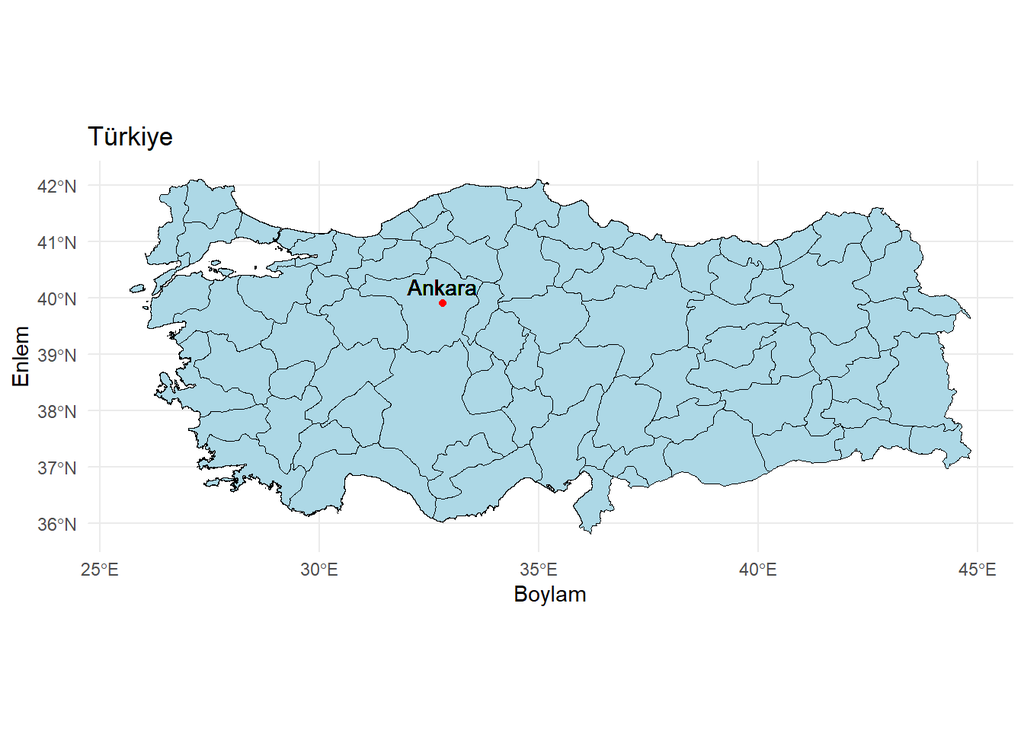

```r
# sadece başkenti göster
ggplot(tr_harita_veri) +
  geom_sf(color = "black", fill = "lightblue") +
  geom_point(aes(32.8, 39.9), color = "red") +
  geom_text(aes(32.8, 40.2), label = "Ankara") +
  coord_sf() +
  xlab("Boylam") + ylab("Enlem") +
  ggtitle("Türkiye") +
  theme_minimal()
```

- Harita üzerinde bölgelerin belirli bazı istatistiklerini renkler ve şekiller yardımıyla göstermek istersek bu bilgilerin bulunduğu veri setiyle geometri bilgisinin bulunduğu veri setini birleştirmemiz gerekir.
- Örnek olarak bkz `tr_harita.R` (R script klasöründe). Bu uygulamada `tr_bolgesel_veri` dosyasında bulunan bazı değişkenler harita üzerinde gösterilmektedir.

## 6.15 `ggplot2` Uzantıları

- `{patchwork}`, `{gganimate}`, `{ggthemes}` vb çok sayıda eklenti geliştirilmiştir.
- Bu eklentileri incelemek için bkz.

https://exts.ggplot2.tidyverse.org/gallery/